# TP Noté de Programmation avec R

Correction

18/12/2019

**Avant d’importer le fichier sur le serveur RStudio, changer son nom avec votre nom et votre prénom.**

**Rendu** : Le code doit être écrit dans les r chunks préformatés. Le fichier de sortie au format .html est à rendre sur Moodle, ou envoyer à l’adresse Servane.Gey@parisdescartes.fr avant 15h. Merci de mettre votre nom et votre prénom dans la partie “author”.

**Notation** : La notation prendra en compte la qualité du code (clarté, nombre de commandes le plus petit possible, rendu compréhensible), en plus de la qualité de la réponse. En particulier, tous les graphiques devront avoir un titre et des légendes appropriés. L’utilisation des librairies vues en cours sera fortement appréciée. **Le barême est indicatif**.

# Exercice 1 (5 points)

On s’intéresse ici aux données *mtcars*, disponibles directement via le logiciel R.

### Question 1

Tracer le nuage de points de la variable *hp* en fonction de *mpg*. Ajouter la droite de régression linéaire sur le graphique.

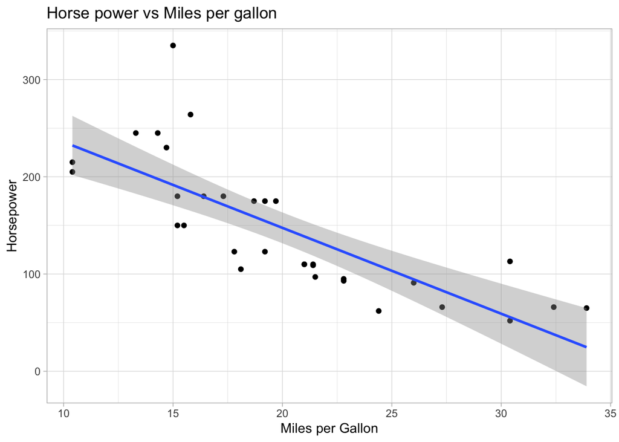

```r
g = ggplot(mtcars, aes(mpg,hp))+geom_point()
g1 = g+geom_smooth(method = "lm")+
  labs(
    title = "Horse power vs Miles per gallon",
    x = "Miles per Gallon",
    y = "Horsepower"
  )+
  theme_light()
g1
```

### Question 2

Tracer les histogrammes en densité de la variable *mpg* suivant les modalités de la variable *cyl*. On pourra éventuellement colorer chaque histogramme.

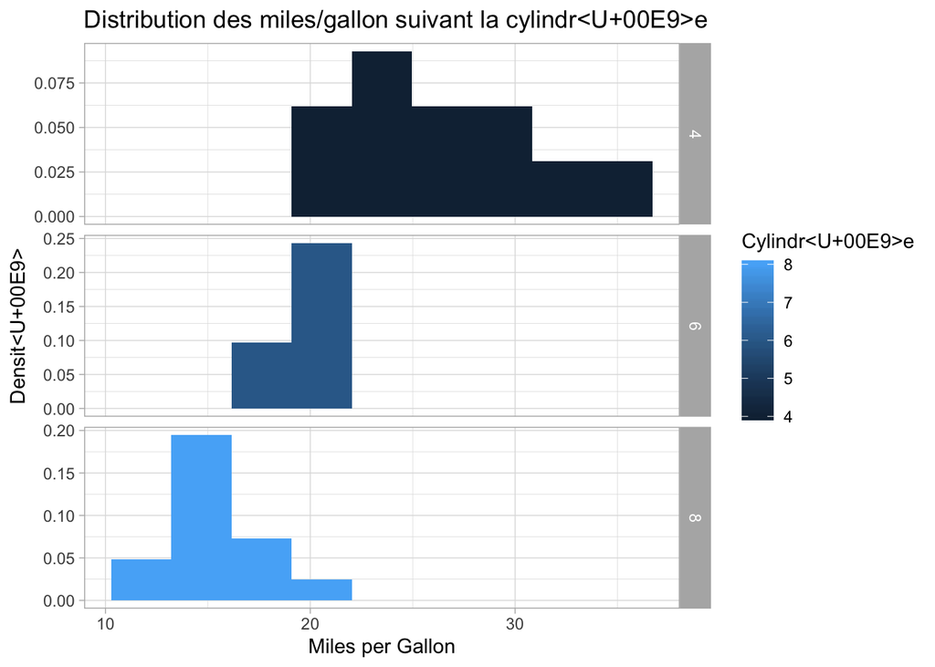

```r
g = ggplot(mtcars, aes(mpg, fill=cyl))
g1 = g+geom_histogram(aes(y=..density..), bins = 9)+
  facet_grid(facets = cyl~., scales = "free_y")+
  labs(
    title = "Distribution des miles/gallon suivant la cylindrée",
    x = "Miles per Gallon",
    y = "Densité",
    fill = "Cylindrée"
       )+
  theme_light()
g1
```

# Exercice 2 (15 points)

Cet exercice porte sur les données de commerces à Paris. Ces données, datant de 2014, recensent tous les commerces de la ville de Paris, leurs types, leurs arrondissements, leurs adresses, leurs longitudes et latitudes, ainsi que d’autres données géographiques.

Importer le fichier *commercesParis.RData* dans le répertoire de travail.

### Question 1

Charger les données avec la commande *load*

```r
load('commercesParis.RData')
```

### Question 2

Extraire de la table :

1. le commerce dont le numéro d’ordre est 86181

```r
commerces %>% filter(ORDRE==86181)
```

| ORDRE | ARRONDISSEMENT | QUARTIER | IRIS | ILOT | NUMERO | LET | TYPE VOIE | LIBELLE VOIE | ADRESSE COMPLETE | CFA | X | Y | XY | SEQUENCE | SITUATION | CODE ACTIVITE | LIBELLE ACTIVITE | SURFACE | CC ID | CC NIV | longitude | latitude |
| --- | --- | --- | --- | --- | --- | --- | --- | --- | --- | --- | --- | --- | --- | --- | --- | --- | --- | --- | --- | --- | --- | --- |
| 86181 | 75016 | 61 | 751166115 | 75116610006 | 137 | NA | AV | VERSAILLES | 137 AV VERSAILLES | 9706 | 646318.3 | 6860510 | 48.842392, 2.268554 | 1 | Sur rue | SA102 | Retouches de vtements | 1 | NA | NA | 2.268554 | 48.842392 |

2. tous les commerces situés au 137 avenue de Versailles

```r
commerces %>% filter(`ADRESSE COMPLETE`=="137 AV VERSAILLES")
```

| ORDRE | ARRONDISSEMENT | QUARTIER | IRIS | ILOT | NUMERO | LET | TYPE VOIE | LIBELLE VOIE | ADRESSE COMPLETE | CFA | X | Y | XY | SEQUENCE | SITUATION | CODE ACTIVITE | LIBELLE ACTIVITE | SURFACE | CC ID | CC NIV | longitude | latitude |
| --- | --- | --- | --- | --- | --- | --- | --- | --- | --- | --- | --- | --- | --- | --- | --- | --- | --- | --- | --- | --- | --- | --- |
| 86181 | 75016 | 61 | 751166115 | 75116610006 | 137 | NA | AV | VERSAILLES | 137 AV VERSAILLES | 9706 | 646318.3 | 6860510 | 48.842392, 2.268554 | 1 | Sur rue | SA102 | Retouches de vtements | 1 | NA | NA | 2.268554 | 48.842392 |
| 58763 | 75016 | 61 | 751166115 | 75116610006 | 137 | NA | AV | VERSAILLES | 137 AV VERSAILLES | 9706 | 646318.3 | 6860510 | 48.842392, 2.268554 | 2 | Sur rue | CH101 | Restaurant traditionnel franais | 1 | NA | NA | 2.268554 | 48.842392 |

3. le nombre de commerces situés avenue de Versailles

```r
commerces %>% filter(`LIBELLE VOIE`=="VERSAILLES") %>% summarise(nombre=n())
```

| nombre |
| --- |
| 226 |

### Question 3

Créer une table au format tibble contenant les informations suivantes : ordre, code activité, libellé activité, adresse complète, numéro, type voie, libellé voie, iris, ilot, quartier, arrondissement, longitude et latitude.

```r
comm = commerces %>% select(
  ORDRE,
  `CODE ACTIVITE`,
  `LIBELLE ACTIVITE`,
  `ADRESSE COMPLETE`,
  NUMERO,
  `TYPE VOIE`,
  `LIBELLE VOIE`,
  IRIS,
  ILOT,
  QUARTIER,
  ARRONDISSEMENT,
  longitude,
  latitude
)
```

### Question 4

1. Créer et afficher la table contenant, pour chaque arrondissement, le nombre de commerces présents.

```r
arrond = comm %>% group_by(ARRONDISSEMENT) %>%
  summarise(nombre = n())
arrond
```

| ARRONDISSEMENT | nombre |
| --- | --- |
| 75001 | 2936 |
| 75002 | 3067 |
| 75003 | 3177 |
| 75004 | 2328 |
| 75005 | 3057 |
| 75006 | 3526 |
| 75007 | 2536 |
| 75008 | 3983 |
| 75009 | 4760 |
| 75010 | 5079 |

[output cut: 10 more lines]

2. Faire un graphique représentant le nombre de commerces par arrondissement.

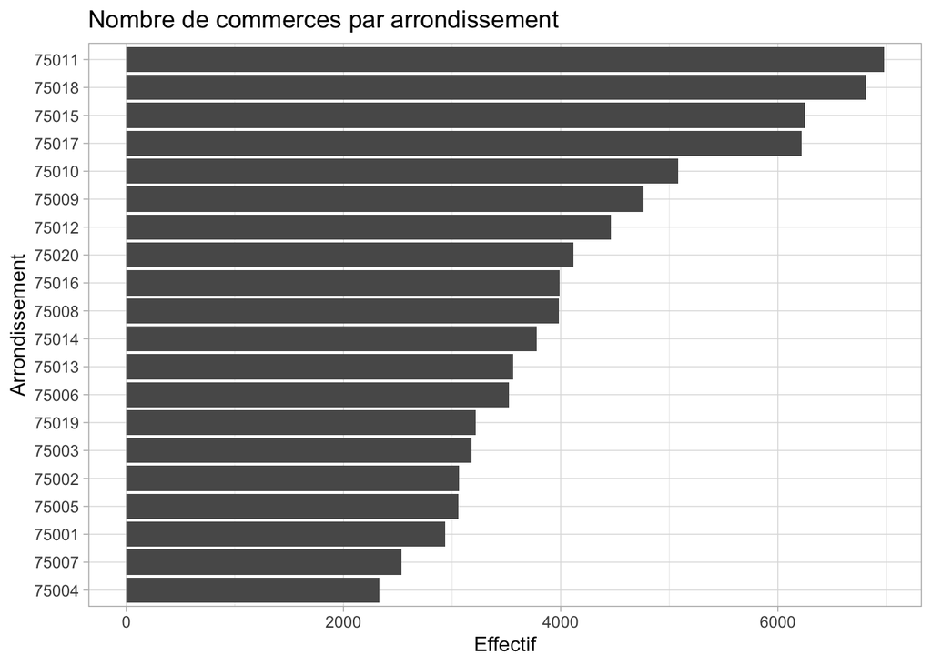

```r
# Création de la table indiquant pour chaque arrondissement le nombre de commerces
comm_nb_type = comm %>% left_join(arrond)

# Création du graphique sous forme de diagramme en barres horizontales ordonnées
g1 = ggplot(
  comm_nb_type,
  aes(
    fct_reorder(ARRONDISSEMENT,
                nombre
                )
    )
  )+
  geom_bar()+
  coord_flip()+
  labs(
    title = "Nombre de commerces par arrondissement",
    x = "Arrondissement",
    y = "Effectif"
  )+
  theme_light()
g1
```

### Question 5

Faire un graphique représentant les 10 types de commerces les plus présents à Paris sous forme de diagramme en barres horizontales, ordonné par ordre croissant.

Indication : voir la fonction *geom_col*.

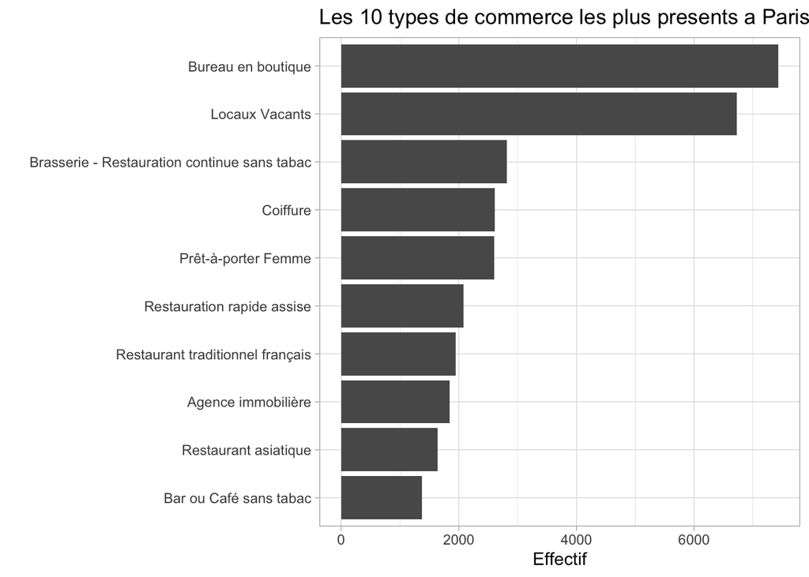

```r
# Création de la table rassemblant le top 10 des types de commerces les plus présents à Paris
top10_activites = comm %>% group_by(`LIBELLE ACTIVITE`) %>%
  summarise(nombre = n()) %>% arrange(desc(nombre)) %>%
  slice(1:10)

# Création du graphique
g3 = ggplot(
  top10_activites,
  aes(
    fct_reorder(`LIBELLE ACTIVITE`, nombre),
    nombre
  )
)+
  geom_col()+
  labs(
    title = "Les 10 types de commerce les plus presents a Paris",
    x = " ",
    y = "Effectif"
  )+
  coord_flip()+
  theme_light()
g3
```

### Question 6

1. Importer les données cartographiques *arrondissements.geojson* des arrondissements de Paris dans le répertoire courant, et charger la carte avec la commande suivante

```r
paris = geojson_read("arrondissements.geojson", what = "sp")
```

2. Créer une table contenant, par arrondissement, le nombre de commerces d’un type choisi parmi les 10 types de commerces les plus présents à Paris.

```r
bureaux = comm %>%
  filter(`LIBELLE ACTIVITE`=="Bureau en boutique") %>%
  group_by(ARRONDISSEMENT) %>%
  summarise(nb_bureaux = n())
```

3. Représenter une carte choroplète par arrondissement du nombre de commerces du type choisi à la question précédente.

```r
# On choisit les bureaux en boutique
# Lorsque l'on essaie de faire la jointure de table, il y a un message d'erreur indiquant que
# les variables arrondissement ne sont pas du même type dans les deux tables
# => changement de la variable dans la table bureau en variable de type integer
bureaux$ARRONDISSEMENT = as.integer(bureaux$ARRONDISSEMENT)

# Ajout de la variable à représenter dans la table des arrondissements de Paris,
# ici le vombre de bureaux en boutique
paris@data = left_join(paris@data, bureaux, by = c("c_ar"="ARRONDISSEMENT"))

# Création de la palette de couleurs suivant la variable à représenter
palette = colorBin("magma",
                   domain = paris$nb_bureaux,
                   bins = seq(50, 850, by = 200)
)

# Création de la carte choroplète
leaflet(paris) %>%
  addTiles() %>%
  addPolygons(
    fillColor = ~palette(nb_bureaux),
    fillOpacity = .5,
    color = "black",
    weight = 1.5,
    opacity = 1
  ) %>%
  addLegend(
    pal = palette,
    values = ~nb_bureaux,
    opacity = .8,
    title = "Nombre de bureaux en boutique",
    position = "topright"
  )
```

[interactive chart not shown]